# HW3-Random forest and Boosting

Guangjin Zhou

April 8, 2019

## library

```r
library(ISLR);library(randomForest); library(gbm)
```

ISLR has a dataset Khan. It contains gene expression data for 4 types of small round blue cell tumors. Use help(Khan) to see details. Apply both random forests and tree boosting to the training set, and tuning the hyperparameters to improve the models. Report your main steps and ???nal results

# Khan data

```r
ls("package:ISLR") ## check package content
```

```
##  [1] "Auto"      "Caravan"   "Carseats"  "College"   "Credit"
##  [6] "Default"   "Hitters"   "Khan"      "NCI60"     "OJ"
## [11] "Portfolio" "Smarket"   "Wage"      "Weekly"
```

```r
mode(Khan) ## List
```

```
## [1] "list"
```

```r
class(Khan) ## List
```

```
## [1] "list"
```

## Check four dataset

```r
dim(Khan$xtrain); dim(Khan$xtest);dim(Khan$ytrain); dim(Khan$ytest)
```

```
## [1]   63 2308
```

```
## [1]   20 2308
```

### xtrain

xtrain contains the 2308 gene expression values for 63 subjects

```r
str(Khan$xtrain);
```

```
##  num [1:63, 1:2308] 0.7733 -0.0782 -0.0845 0.9656 0.0757 ...
##  - attr(*, "dimnames")=List of 2
##   ..$ : chr [1:63] "V1" "V2" "V3" "V4" ...
##   ..$ : NULL
```

### xtest

xtest contains 20 test sample gene expression value

```r
str(Khan$xtest);
```

```
##  num [1:20, 1:2308] 0.14 1.164 0.841 0.685 -1.956 ...
##  - attr(*, "dimnames")=List of 2
##   ..$ : chr [1:20] "V1" "V2" "V4" "V6" ...
##   ..$ : NULL
```

### ytrain

ytrain records the corresponding tumor type for 63 subjects

```r
table(Khan$ytrain)
```

```
##
##  1  2  3  4
##  8 23 12 20
```

```r
str(Khan$ytrain)
```

```
##  num [1:63] 2 2 2 2 2 2 2 2 2 2 ...
```

### ytest

y test 20 different test sample tumor type

```r
table(Khan$ytest)
```

```
##
## 1 2 3 4
## 3 6 6 5
```

```r
str(Khan$ytest)
```

```
##  num [1:20] 3 2 4 2 1 3 4 2 3 1 ...
```

# Trainging dataset

```r
khan.train <- data.frame(x = Khan$xtrain, y = as.factor(Khan$ytrain))
str(khan.train)
```

```
## 'data.frame':    63 obs. of  2309 variables:
##  $ x.1   : num  0.7733 -0.0782 -0.0845 0.9656 0.0757 ...
##  $ x.2   : num  -2.44 -2.42 -1.65 -2.38 -1.73 ...
##  $ x.3   : num  -0.483 0.413 -0.241 0.625 0.853 ...
##  $ x.4   : num  -2.721 -2.825 -2.875 -1.741 0.273 ...
##  $ x.5   : num  -1.217 -0.626 -0.889 -0.845 -1.841 ...
##  $ x.6   : num  0.8278 0.0545 -0.0275 0.9497 0.3279 ...
##  $ x.7   : num  1.34 1.43 1.16 1.09 1.25 ...
##  $ x.8   : num  0.057 -0.1202 0.0157 0.8197 0.7714 ...
##  $ x.9   : num  0.1336 0.4568 0.1919 -0.2846 0.0309 ...
##  $ x.10  : num  0.565 0.159 0.497 0.995 0.278 ...
##  $ x.11  : num  1.5 1.15 1.39 1.01 1.11 ...
##  $ x.12  : num  0.3936 0.3807 -0.5307 0.0825 -0.3936 ...
##  $ x.13  : num  1.63 1.56 1.61 1.05 1.19 ...
##  $ x.14  : num  0.81819 0.00817 -0.20801 0.97203 0.41805 ...
```

[output cut: 86 more lines]

```r
dim(khan.train)
```

```
## [1]   63 2309
```

```r
head(khan.train)
```

[output not shown]

[output cut: 2633 more lines]

[output not shown]

# Random Forest model with default hyperparameter setting

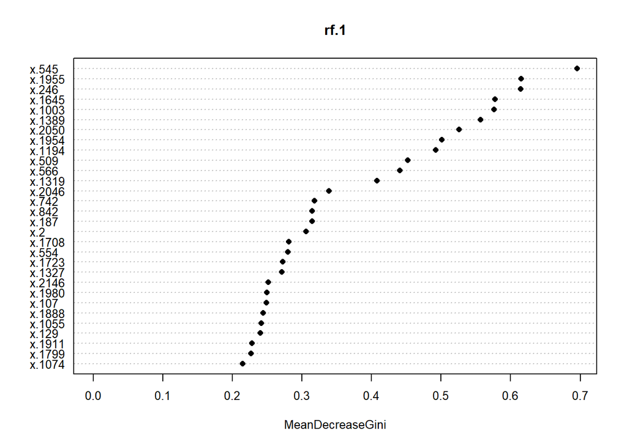

```r
set.seed(471)
rf.1 <- randomForest(y ~. , data=khan.train, proximity=FALSE, importance=TRUE, ntree=1000, maxdepth=5, na.action=na.roughfix)

varImpPlot(rf.1, type=2, cex=.8, color="black",pch=16, scale=T)
```

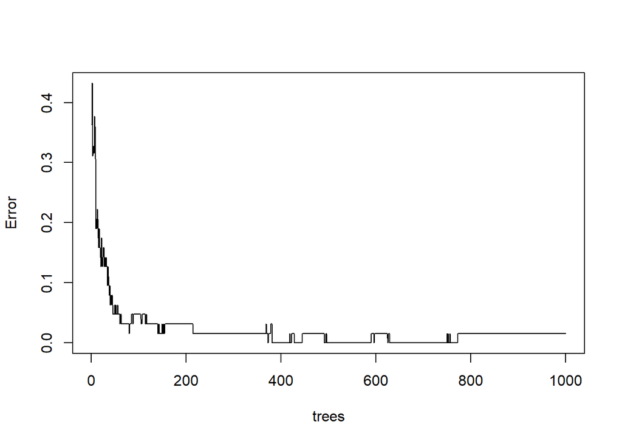

```r
plot(rf.1$err.rate[,1], type='l', xlab='trees', ylab='Error')
```

## M hyperparameter tuning

```r
set.seed(471)
rf.1 <- randomForest(y ~. , data=khan.train, proximity=FALSE, importance=TRUE, ntree=1000, maxdepth=5, na.action=na.roughfix, mtry=1)
rf.10 <- randomForest(y ~. , data=khan.train, proximity=FALSE, importance=TRUE, ntree=1000, maxdepth=5, na.action=na.roughfix, mtry=10)
rf.100 <- randomForest(y ~. , data=khan.train, proximity=FALSE, importance=TRUE, ntree=1000, maxdepth=5, na.action=na.roughfix, mtry=100)

rf.1000 <- randomForest(y ~. , data=khan.train, proximity=FALSE, importance=TRUE, ntree=1000, maxdepth=5, na.action=na.roughfix, mtry=1000)
```

## Variance importance plots

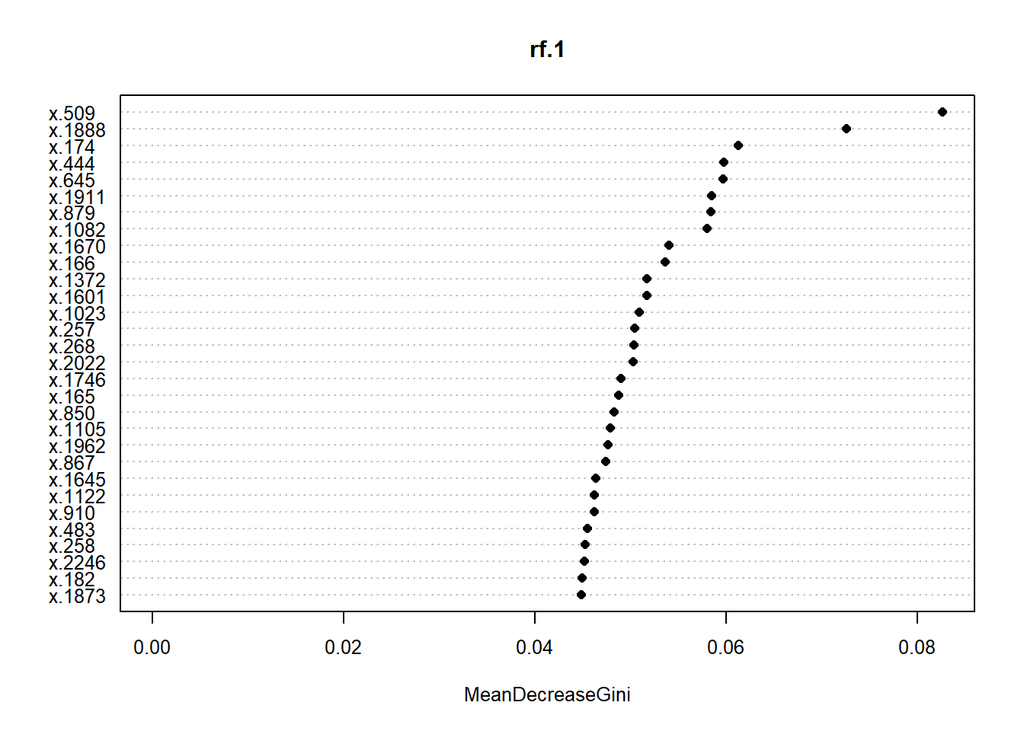

```r
varImpPlot(rf.1, type=2, cex=.8, color="black",pch=16, scale=T)
```

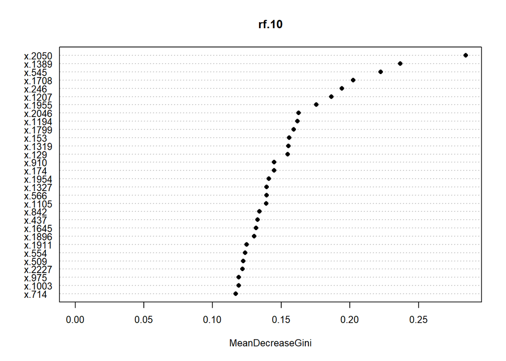

```r
varImpPlot(rf.10, type=2, cex=.8, color="black",pch=16, scale=T)
```

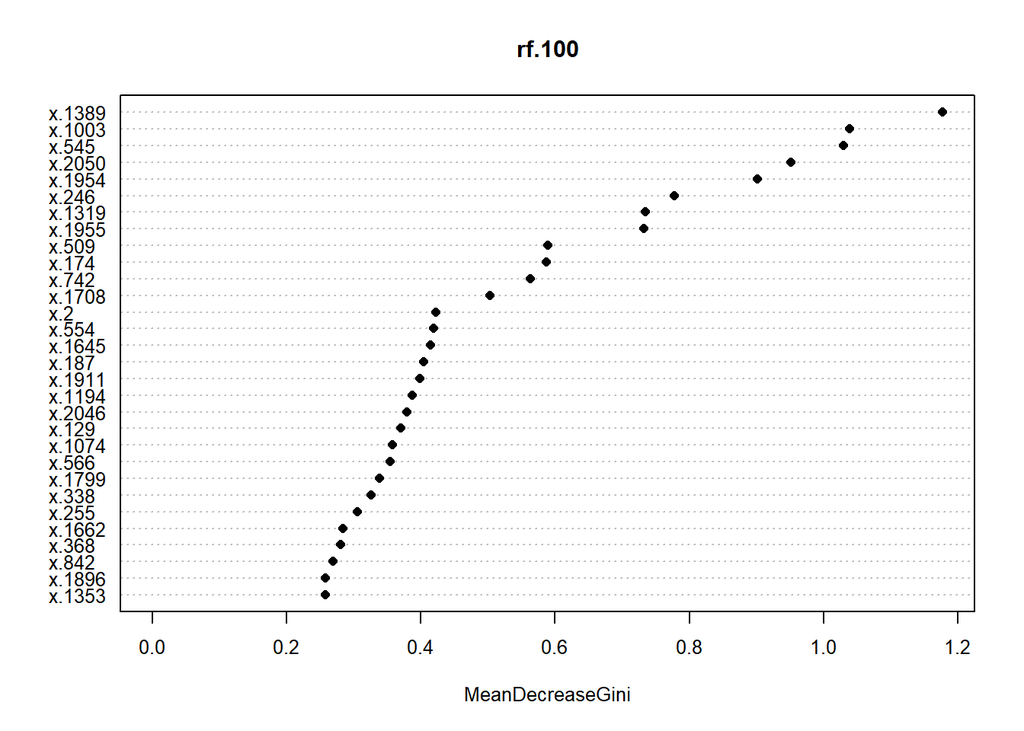

```r
varImpPlot(rf.100, type=2, cex=.8, color="black",pch=16, scale=T)
```

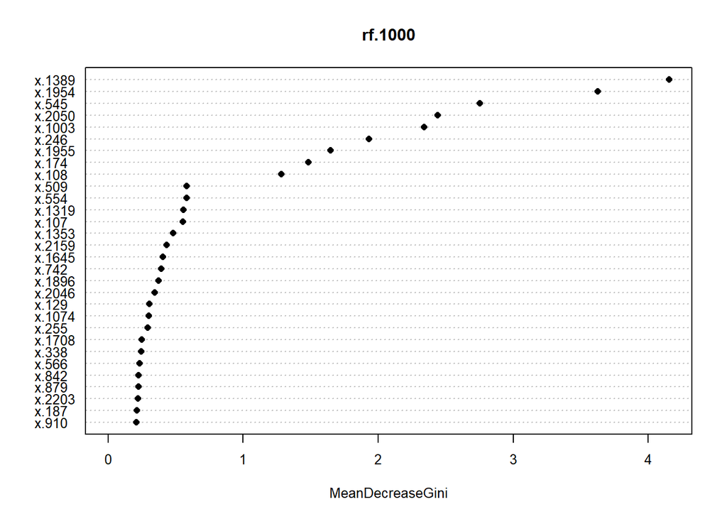

```r
varImpPlot(rf.1000, type=2, cex=.8, color="black",pch=16, scale=T)
```

I tried the models with the hyperpameter for 1, 10, 100, 1000, sounds 1000, looks I need at least 100 for a good random forest model to show variance importance.

# Boosting model

## A model with 1000 trees

```r
set.seed(2019)
bt = gbm(y ~ ., data=khan.train, distribution="gaussian", n.trees=1000)
bt
```

```
## gbm(formula = y ~ ., distribution = "gaussian", data = khan.train,
##     n.trees = 1000)
## A gradient boosted model with gaussian loss function.
## 1000 iterations were performed.
## There were 2308 predictors of which 719 had non-zero influence.
```

```r
names(bt)
```

```
##  [1] "initF"             "fit"               "train.error"
##  [4] "valid.error"       "oobag.improve"     "trees"
##  [7] "c.splits"          "bag.fraction"      "distribution"
## [10] "interaction.depth" "n.minobsinnode"    "num.classes"
## [13] "n.trees"           "nTrain"            "train.fraction"
## [16] "response.name"     "shrinkage"         "var.levels"
## [19] "var.monotone"      "var.names"         "var.type"
## [22] "verbose"           "data"              "Terms"
## [25] "cv.folds"          "call"              "m"
```

## Different tree numbers models

```r
set.seed(2019)
bt1 <- gbm(y ~ ., data=khan.train,  distribution = "gaussian", n.trees = 200)
bt2 <- gbm(y ~ ., data=khan.train,  distribution = "gaussian", n.trees = 1000)
bt3 <- gbm(y ~ ., data=khan.train,  distribution = "gaussian", n.trees = 5000)
```

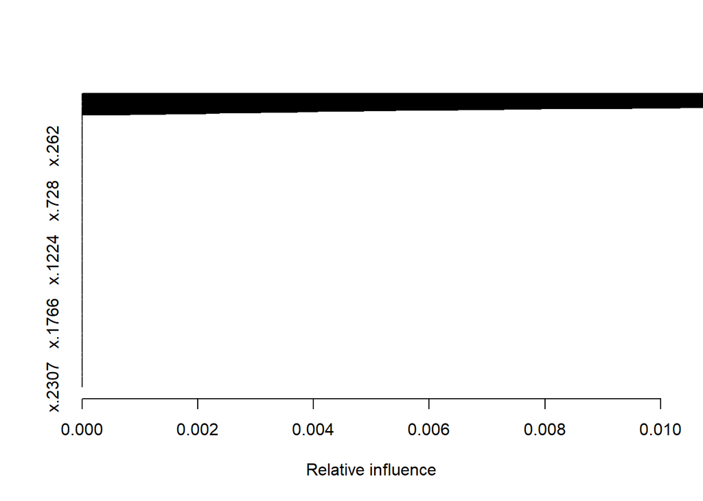

```
##           var      rel.inf
## x.1194 x.1194 1.695433e+01
## x.1003 x.1003 1.369362e+01
## x.2046 x.2046 9.888269e+00
## x.1706 x.1706 7.212669e+00
## x.1536 x.1536 4.559422e+00
## x.2238 x.2238 4.514913e+00
## x.1888 x.1888 4.218517e+00
## x.187   x.187 4.082037e+00
## x.141   x.141 3.636560e+00
## x.1634 x.1634 3.201771e+00
## x.469   x.469 3.043345e+00
## x.1760 x.1760 2.818827e+00
## x.941   x.941 2.350458e+00
## x.1207 x.1207 2.118440e+00
## x.849   x.849 1.901585e+00
## x.188   x.188 1.345198e+00
## x.1395 x.1395 1.297561e+00
## x.1677 x.1677 1.247810e+00
## x.335   x.335 9.140085e-01
## x.1627 x.1627 7.863130e-01
## x.632   x.632 7.494912e-01
## x.1749 x.1749 6.713687e-01
## x.1853 x.1853 6.239822e-01
## x.589   x.589 5.863168e-01
## x.1090 x.1090 5.108281e-01
## x.883   x.883 4.183237e-01
## x.1883 x.1883 4.036805e-01
## x.1884 x.1884 3.973501e-01
## x.1606 x.1606 3.464776e-01
## x.933   x.933 2.985336e-01
## x.486   x.486 2.972984e-01
## x.166   x.166 2.379986e-01
## x.503   x.503 2.145083e-01
## x.682   x.682 2.074531e-01
## x.1975 x.1975 2.011516e-01
## x.2164 x.2164 1.825977e-01
## x.1308 x.1308 1.682397e-01
## x.1905 x.1905 1.672268e-01
## x.1964 x.1964 1.671019e-01
```

[output cut: 2254 more lines]

```
## x.2292 x.2292 0.000000e+00
## x.2293 x.2293 0.000000e+00
## x.2294 x.2294 0.000000e+00
## x.2296 x.2296 0.000000e+00
## x.2297 x.2297 0.000000e+00
## x.2298 x.2298 0.000000e+00
## x.2299 x.2299 0.000000e+00
## x.2300 x.2300 0.000000e+00
## x.2301 x.2301 0.000000e+00
## x.2302 x.2302 0.000000e+00
## x.2303 x.2303 0.000000e+00
## x.2304 x.2304 0.000000e+00
## x.2305 x.2305 0.000000e+00
## x.2306 x.2306 0.000000e+00
## x.2307 x.2307 0.000000e+00
```

```r
summary(bt1,xlim=c(0,0.01))
```

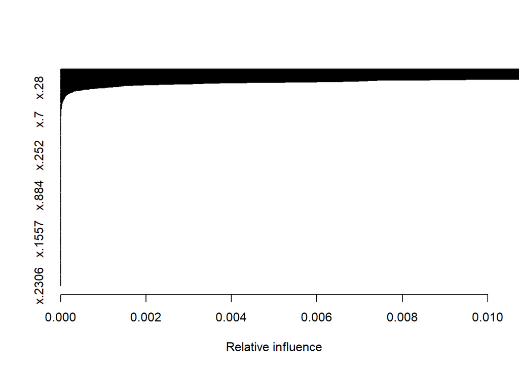

```
##           var      rel.inf
## x.1003 x.1003 1.431668e+01
## x.1706 x.1706 1.094302e+01
## x.1888 x.1888 1.064320e+01
## x.1822 x.1822 8.204855e+00
## x.188   x.188 7.820813e+00
## x.187   x.187 5.556759e+00
## x.1536 x.1536 4.444629e+00
## x.1634 x.1634 3.847572e+00
## x.1194 x.1194 3.809516e+00
## x.1782 x.1782 3.173183e+00
## x.979   x.979 2.391541e+00
## x.2046 x.2046 2.026658e+00
## x.1237 x.1237 1.614225e+00
## x.76     x.76 1.595061e+00
## x.1838 x.1838 1.574888e+00
## x.1896 x.1896 1.393840e+00
## x.558   x.558 1.289090e+00
## x.2146 x.2146 1.227463e+00
## x.1125 x.1125 1.025142e+00
## x.774   x.774 9.320423e-01
## x.1606 x.1606 8.281629e-01
## x.1760 x.1760 7.846512e-01
## x.1884 x.1884 6.950637e-01
## x.2273 x.2273 6.924055e-01
## x.1453 x.1453 6.915406e-01
## x.1393 x.1393 6.560412e-01
## x.638   x.638 6.545597e-01
## x.1318 x.1318 6.152020e-01
## x.2305 x.2305 5.520137e-01
## x.1595 x.1595 4.409575e-01
## x.719   x.719 3.962036e-01
## x.2247 x.2247 2.718094e-01
## x.1247 x.1247 2.608447e-01
## x.1207 x.1207 2.496811e-01
## x.1322 x.1322 2.332569e-01
## x.362   x.362 2.251173e-01
## x.1353 x.1353 2.082122e-01
## x.1002 x.1002 1.909040e-01
## x.586   x.586 1.895025e-01
```

[output cut: 2254 more lines]

```
## x.2283 x.2283 0.000000e+00
## x.2285 x.2285 0.000000e+00
## x.2286 x.2286 0.000000e+00
## x.2287 x.2287 0.000000e+00
## x.2288 x.2288 0.000000e+00
## x.2290 x.2290 0.000000e+00
## x.2291 x.2291 0.000000e+00
## x.2293 x.2293 0.000000e+00
## x.2297 x.2297 0.000000e+00
## x.2298 x.2298 0.000000e+00
## x.2299 x.2299 0.000000e+00
## x.2300 x.2300 0.000000e+00
## x.2301 x.2301 0.000000e+00
## x.2302 x.2302 0.000000e+00
## x.2306 x.2306 0.000000e+00
```

```r
summary(bt2,xlim=c(0,0.01))
```

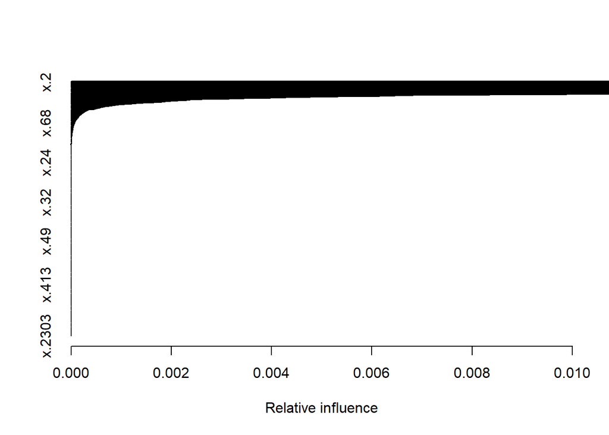

```
##           var      rel.inf
## x.1194 x.1194 2.045955e+01
## x.509   x.509 9.449733e+00
## x.1727 x.1727 8.912850e+00
## x.1110 x.1110 6.544970e+00
## x.554   x.554 5.455560e+00
## x.187   x.187 5.366554e+00
## x.1003 x.1003 4.879353e+00
## x.2       x.2 3.562628e+00
## x.151   x.151 3.419604e+00
## x.1536 x.1536 3.361274e+00
## x.129   x.129 2.334274e+00
## x.1634 x.1634 2.241649e+00
## x.2046 x.2046 1.841166e+00
## x.469   x.469 1.687576e+00
## x.166   x.166 1.598662e+00
## x.2146 x.2146 1.555253e+00
## x.335   x.335 1.310033e+00
## x.585   x.585 1.252238e+00
## x.970   x.970 1.088249e+00
## x.1937 x.1937 1.054969e+00
## x.276   x.276 9.862662e-01
## x.1677 x.1677 9.445433e-01
## x.1610 x.1610 8.009515e-01
## x.326   x.326 7.496462e-01
## x.1916 x.1916 6.441240e-01
## x.866   x.866 5.551188e-01
## x.1735 x.1735 4.618670e-01
## x.1811 x.1811 4.406278e-01
## x.1217 x.1217 4.032656e-01
## x.1098 x.1098 3.927753e-01
## x.1208 x.1208 3.413105e-01
## x.2081 x.2081 3.239911e-01
## x.1884 x.1884 2.974336e-01
## x.2164 x.2164 2.797416e-01
## x.1647 x.1647 2.783009e-01
## x.1427 x.1427 2.671040e-01
## x.1741 x.1741 2.288048e-01
## x.1055 x.1055 2.158309e-01
## x.1706 x.1706 1.775561e-01
```

[output cut: 2254 more lines]

```
## x.2232 x.2232 0.000000e+00
## x.2233 x.2233 0.000000e+00
## x.2237 x.2237 0.000000e+00
## x.2248 x.2248 0.000000e+00
## x.2249 x.2249 0.000000e+00
## x.2256 x.2256 0.000000e+00
## x.2262 x.2262 0.000000e+00
## x.2263 x.2263 0.000000e+00
## x.2264 x.2264 0.000000e+00
## x.2271 x.2271 0.000000e+00
## x.2276 x.2276 0.000000e+00
## x.2279 x.2279 0.000000e+00
## x.2285 x.2285 0.000000e+00
## x.2296 x.2296 0.000000e+00
## x.2303 x.2303 0.000000e+00
```

```r
summary(bt3,xlim=c(0,0.01))
```

## Change shrinkag parmater

```r
set.seed(2019)
bt4 <- gbm(y ~ ., data=khan.train,  distribution = "gaussian", n.trees = 5000, shrinkage = 0.01)
bt5 <- gbm(y ~ ., data=khan.train,  distribution = "gaussian", n.trees = 5000,shrinkage = 0.1)
bt6 <- gbm(y ~ ., data=khan.train,  distribution = "gaussian", n.trees = 5000,shrinkage = 0.5)
```

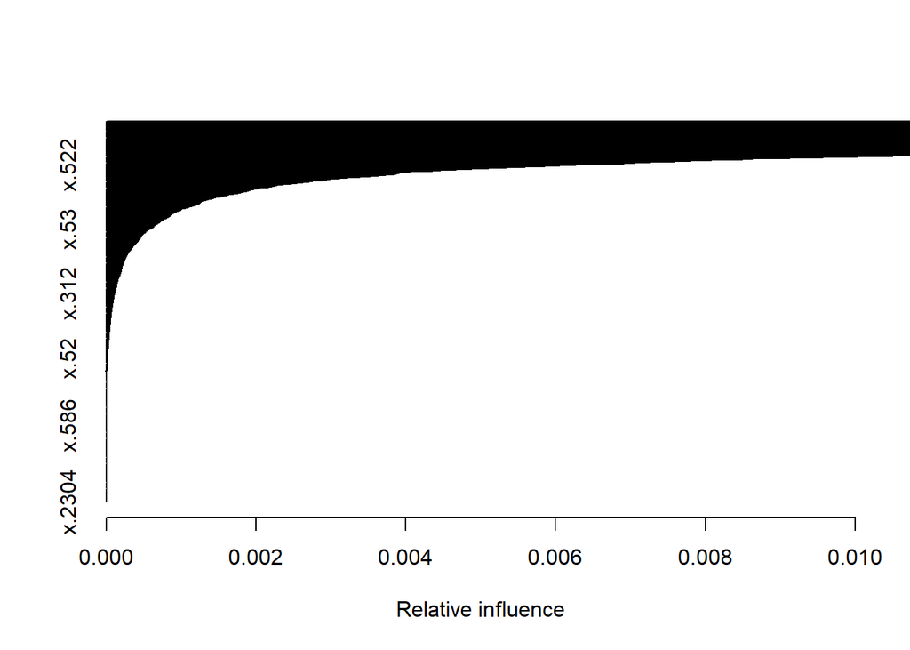

```
##           var      rel.inf
## x.1194 x.1194 1.860224e+01
## x.1003 x.1003 8.811247e+00
## x.2046 x.2046 7.508081e+00
## x.1706 x.1706 6.491269e+00
## x.509   x.509 3.972827e+00
## x.1888 x.1888 3.167740e+00
## x.1536 x.1536 2.689434e+00
## x.187   x.187 2.634157e+00
## x.153   x.153 2.170795e+00
## x.1634 x.1634 2.071161e+00
## x.129   x.129 1.523045e+00
## x.2146 x.2146 1.487194e+00
## x.188   x.188 1.475823e+00
## x.1760 x.1760 1.423681e+00
## x.1994 x.1994 1.380389e+00
## x.1207 x.1207 1.310733e+00
## x.1606 x.1606 1.289861e+00
## x.1110 x.1110 1.252503e+00
## x.979   x.979 1.094719e+00
## x.141   x.141 1.046137e+00
## x.1723 x.1723 1.043347e+00
## x.1093 x.1093 1.011284e+00
## x.2238 x.2238 9.960687e-01
## x.1911 x.1911 9.763682e-01
## x.761   x.761 9.099819e-01
## x.849   x.849 8.959434e-01
## x.1090 x.1090 8.738029e-01
## x.174   x.174 8.682680e-01
## x.970   x.970 7.897924e-01
## x.1610 x.1610 7.777359e-01
## x.2247 x.2247 7.164091e-01
## x.910   x.910 7.053637e-01
## x.733   x.733 6.800275e-01
## x.1937 x.1937 6.224129e-01
## x.1345 x.1345 6.213147e-01
## x.151   x.151 6.081649e-01
## x.941   x.941 5.558691e-01
## x.335   x.335 4.965451e-01
## x.1393 x.1393 4.555942e-01
```

[output cut: 2254 more lines]

```
## x.2241 x.2241 0.000000e+00
## x.2242 x.2242 0.000000e+00
## x.2244 x.2244 0.000000e+00
## x.2253 x.2253 0.000000e+00
## x.2256 x.2256 0.000000e+00
## x.2261 x.2261 0.000000e+00
## x.2263 x.2263 0.000000e+00
## x.2265 x.2265 0.000000e+00
## x.2271 x.2271 0.000000e+00
## x.2272 x.2272 0.000000e+00
## x.2276 x.2276 0.000000e+00
## x.2284 x.2284 0.000000e+00
## x.2297 x.2297 0.000000e+00
## x.2299 x.2299 0.000000e+00
## x.2304 x.2304 0.000000e+00
```

```r
summary(bt4,xlim=c(0,0.01))
```

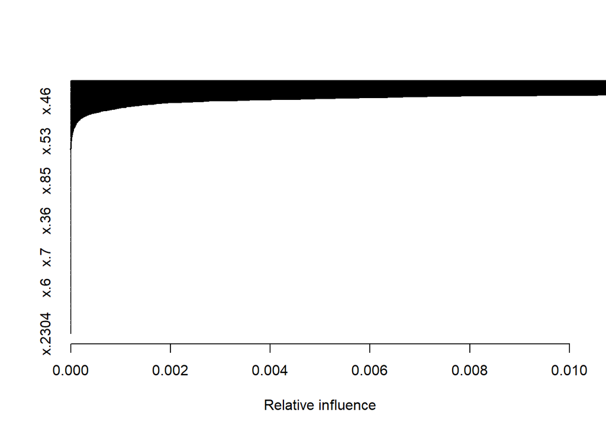

```
##           var      rel.inf
## x.1194 x.1194 1.168680e+01
## x.1003 x.1003 1.027268e+01
## x.469   x.469 7.899155e+00
## x.129   x.129 7.820037e+00
## x.187   x.187 6.301484e+00
## x.1888 x.1888 6.220333e+00
## x.1536 x.1536 5.504426e+00
## x.2046 x.2046 4.842307e+00
## x.188   x.188 4.176733e+00
## x.1955 x.1955 3.376082e+00
## x.1706 x.1706 3.205202e+00
## x.2146 x.2146 2.315661e+00
## x.1245 x.1245 2.088453e+00
## x.1237 x.1237 1.937314e+00
## x.640   x.640 1.752249e+00
## x.808   x.808 1.700307e+00
## x.440   x.440 1.583673e+00
## x.554   x.554 1.511371e+00
## x.2081 x.2081 1.165580e+00
## x.2235 x.2235 9.754228e-01
## x.1647 x.1647 7.448241e-01
## x.849   x.849 7.433467e-01
## x.457   x.457 7.358719e-01
## x.941   x.941 7.125391e-01
## x.230   x.230 5.897442e-01
## x.279   x.279 4.778514e-01
## x.409   x.409 4.425556e-01
## x.2088 x.2088 4.260321e-01
## x.1916 x.1916 4.005042e-01
## x.1208 x.1208 3.808623e-01
## x.1207 x.1207 3.775696e-01
## x.2306 x.2306 3.253002e-01
## x.1196 x.1196 2.661908e-01
## x.2301 x.2301 2.642242e-01
## x.1093 x.1093 2.583544e-01
## x.1937 x.1937 2.387083e-01
## x.774   x.774 2.253409e-01
## x.326   x.326 2.226524e-01
## x.1055 x.1055 2.097419e-01
```

[output cut: 2254 more lines]

```
## x.2205 x.2205 0.000000e+00
## x.2209 x.2209 0.000000e+00
## x.2212 x.2212 0.000000e+00
## x.2217 x.2217 0.000000e+00
## x.2241 x.2241 0.000000e+00
## x.2253 x.2253 0.000000e+00
## x.2254 x.2254 0.000000e+00
## x.2256 x.2256 0.000000e+00
## x.2258 x.2258 0.000000e+00
## x.2266 x.2266 0.000000e+00
## x.2267 x.2267 0.000000e+00
## x.2276 x.2276 0.000000e+00
## x.2291 x.2291 0.000000e+00
## x.2297 x.2297 0.000000e+00
## x.2304 x.2304 0.000000e+00
```

```r
summary(bt5,xlim=c(0,0.01))
```

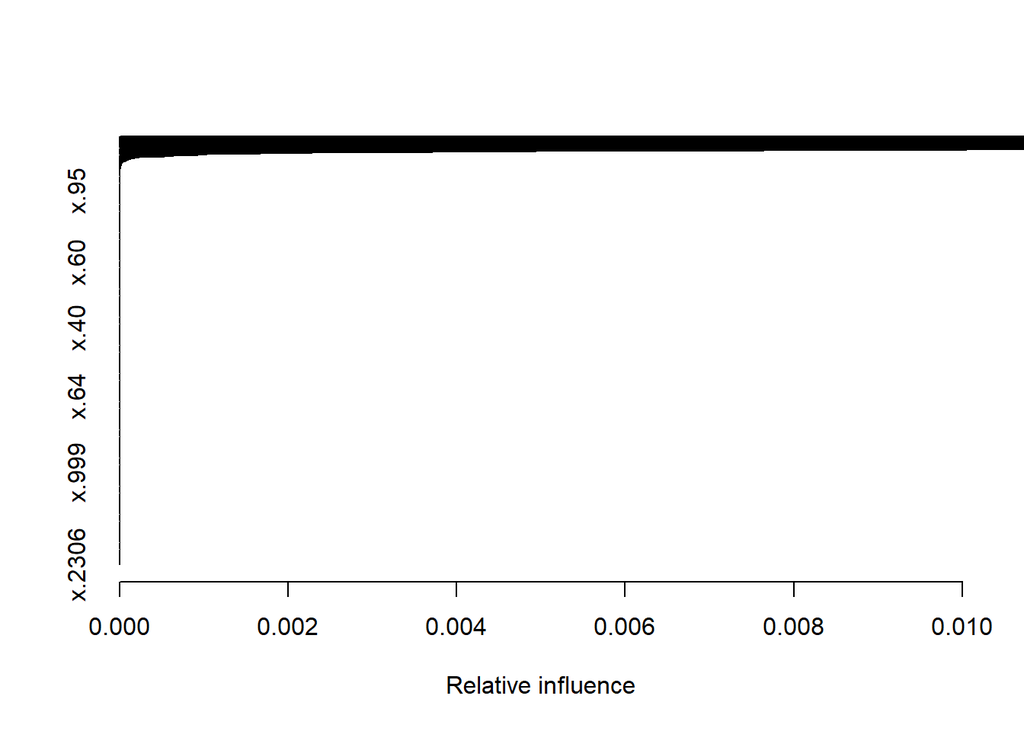

```
##           var      rel.inf
## x.1706 x.1706 2.811399e+01
## x.1822 x.1822 1.524476e+01
## x.682   x.682 6.286577e+00
## x.509   x.509 5.945434e+00
## x.825   x.825 4.258416e+00
## x.997   x.997 3.958979e+00
## x.1860 x.1860 3.720134e+00
## x.847   x.847 3.259045e+00
## x.985   x.985 3.178394e+00
## x.544   x.544 2.590263e+00
## x.2055 x.2055 2.463455e+00
## x.541   x.541 1.945133e+00
## x.266   x.266 1.551301e+00
## x.708   x.708 1.542908e+00
## x.1710 x.1710 1.498673e+00
## x.2186 x.2186 1.150907e+00
## x.1497 x.1497 1.147792e+00
## x.1410 x.1410 1.116020e+00
## x.1239 x.1239 1.092181e+00
## x.1442 x.1442 1.066170e+00
## x.297   x.297 7.776727e-01
## x.1520 x.1520 7.149140e-01
## x.1611 x.1611 6.551226e-01
## x.1207 x.1207 6.180860e-01
## x.974   x.974 5.404228e-01
## x.62     x.62 5.375005e-01
## x.1688 x.1688 4.167161e-01
## x.1242 x.1242 4.094782e-01
## x.1159 x.1159 4.035604e-01
## x.280   x.280 2.807523e-01
## x.1179 x.1179 2.771596e-01
## x.803   x.803 2.729510e-01
## x.1148 x.1148 2.676033e-01
## x.289   x.289 2.611675e-01
## x.259   x.259 2.604898e-01
## x.477   x.477 2.153953e-01
## x.132   x.132 1.491526e-01
## x.1934 x.1934 1.432606e-01
## x.476   x.476 1.163795e-01
```

[output cut: 2254 more lines]

```
## x.2273 x.2273 0.000000e+00
## x.2276 x.2276 0.000000e+00
## x.2281 x.2281 0.000000e+00
## x.2282 x.2282 0.000000e+00
## x.2285 x.2285 0.000000e+00
## x.2286 x.2286 0.000000e+00
## x.2289 x.2289 0.000000e+00
## x.2290 x.2290 0.000000e+00
## x.2292 x.2292 0.000000e+00
## x.2298 x.2298 0.000000e+00
## x.2300 x.2300 0.000000e+00
## x.2301 x.2301 0.000000e+00
## x.2304 x.2304 0.000000e+00
## x.2305 x.2305 0.000000e+00
## x.2306 x.2306 0.000000e+00
```

```r
summary(bt6,xlim=c(0,0.01))
```